# Bertomeu, Ma, and Marinovic (2020, TAR)

Shunsuke Matsuno

2021/07/29

# Required Libraries

```r
pacman::p_load(tidyverse, ggplot2, patchwork, BertomeuMaMarinovic)
```

# Introduction

- This note simulates BMM (2020).
- Static model is omitted.

# Multi-period Model

## Fixed point of $\Gamma$

- We simulate $\Gamma$ to see numerically that the function has a unique fixed point in the negative region.
- The function is given by
  $$\Gamma(y) = \frac{1-p_{t}}{p_{t}}\int_{-\infty}^{\infty}\frac{x_{t}}{\sigma_{x}}\phi\left(\frac{x_{t}+y}{\sigma_{x}}\right)\Phi\left(-\alpha x_{t}-\beta\right)dx_{t}.$$
  - Note that the function involves an integration.
- We use a simple Monte Carlo method to to evaluate $\Gamma(y)$.
  - Fix $y$.
  - By the change of variable $\xi_t = \frac{x_t + y}{\sigma_x}$, the integral is written as
    $$\begin{align*}
    \int_{-\infty}^{\infty} & \frac{x_{t}}{\sigma_{x}}\phi\left(\frac{x_{t}+y}{\sigma_{x}}\right)\Phi\left(-\alpha x_{t}-\beta\right)dx_{t}\\
    & =\int_{-\infty}^{\infty}\left(\xi_{t}-\frac{y}{\sigma_{x}}\right)\phi\left(\xi_{t}\right)\Phi\left(-\alpha\sigma_{x}\xi_{t}+\alpha y-\beta\right)\sigma_{x}d\xi_{t}
    \end{align*}$$
  - Write $g(\xi_{t})=\left(\xi_{t}-\frac{y}{\sigma_{x}}\right)\Phi\left(-\alpha\sigma_{x}\xi_{t}+\alpha y-\beta\right)\sigma_{x}$, so the integral is
    $$\int_{-\infty}^{\infty}g(\xi_{t})\phi(\xi_{t})d\xi_{t}.$$
  - Therefore, by simulating $\{\xi_t^s \}_{s=1}^{M}$ from $\mathcal{N}(0,1)$, we have
    $$M^{-1}\sum_{s=1}^{M}g(\xi_{t}^{s})\to_{p}\mathbb{E}[g(\xi_{t})]=\int_{-\infty}^{\infty}g(\xi_{t})\phi(\xi_{t})d\xi_{t}.$$
  - We could use more sophisticated methods of numerical integration, but this simple Monte Carlo method suffices for our purpose.
    - For example, try importance sampling.
- Here is the code for $\Gamma(y)$.
  - Note that $\Gamma$ depends on $(p_{t},\sigma_{x},\alpha,\beta)$, which are treated as parameters.

```r
# the definition of Gamma
compute_Gamma
```

```
## function(p, sigma_x, alpha, beta, xi_random,
##                           interval = c(-1.5, .5)){
##   # @description
##   #  Returns the function that defines P_nd as a fixed point.
##   #  Uses spline interpolation and returns the splined function
##   #
##   # @note
##   #  `xi_random` is used for Monte Carlo integration.
##
##
##   # integrand
##   g <- function(xi, y, p, sigma_x, alpha, beta){
##     (xi - y/sigma_x) * pnorm(-alpha * sigma_x * xi + alpha * y - beta) * sigma_x
##   }
##   g <- Vectorize(g, "xi")
##
##   # Integral
##   compute_Gamma_val <- function(y, xi_random,
##                         p, sigma_x, alpha, beta){
##     # returns Gamma for each y
##     I <- mean(g(xi_random, y, p, sigma_x, alpha, beta))
##     return((1-p)/p * I)
##   }
##
##   # simulate normal variables and take mean
##   df_Gamma <- tibble(y = seq(interval[1], interval[2], .1)) %>%
##     mutate(Gamma_val = map_dbl(.x = y, .f = compute_Gamma_val, xi = xi_random,
##                                p = p, sigma_x = sigma_x, alpha = alpha, beta = beta))
##   Gamma_splined <- splinefun(x = df_Gamma %>% pull(y),
##                              y = df_Gamma %>% pull(Gamma_val))
##
##   return(list(df = df_Gamma, fun = Gamma_splined))
## }
## <bytecode: 0x000000001ec22690>
## <environment: namespace:BertomeuMaMarinovic>
```

- For a set of parameters, we plot $\Gamma(p)$.
  - The parameter values are take from Table 5.
  - By changing parameter values (and the range of $y$), we can verify that a unique fixed point exists in the negative region.

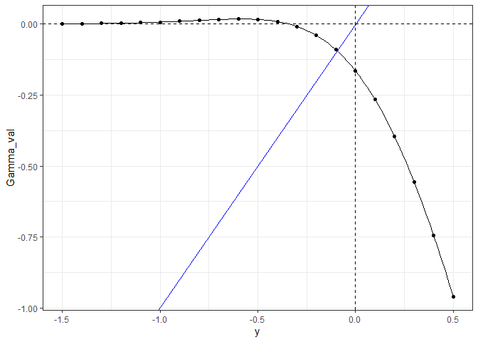

```r
# parameters
p <- .3
sigma_x <- .32
alpha <- 2.54
beta <- .67

# simulation
Gamma_simulated <- compute_Gamma(p, sigma_x, alpha, beta,
                                 xi_random = rnorm(1e4))

# plot
ggplot(Gamma_simulated$df, aes(y, Gamma_val)) +
  geom_point() +
  stat_function(fun = Gamma_simulated$fun) +
  geom_abline(slope = 1, intercept = 0, colour = "blue") +
  geom_vline(xintercept = 0, lty = 2) +
  geom_hline(yintercept = 0, lty = 2) +
  theme_bw()
```

## Simulating Dyunamic Behavior

```r
set.seed(2021)

# parameters
p <- .35
sigma_x <- .32
sigma_e <- .74
alpha <- 2.54
beta <- .67
p_11 <- .8    # Phi(1 | 1): prob of theta = 1 to 1
p_01 <- .2     # Phi(1 | 0): prob of theta = 0 to 1

# data length
N <- 3 * 1e3
Time <- 10
```

- First, we simulate $\theta$, the value of friction.
  - We draw tge initial value of $\theta_t$ from the Beta distribution.
  - The evolution is governed by `p_11` and `p_01`.
  - $p_t = \mathbb{E}[\theta_t]$ is also computed.

```r
# function that generates next theta by FOM
simulate_friction
```

```
## function(Time, p_11, p_01, p_init = p_01/(1 - p_11 + p_01), n){
##   # @description
##   # We first compute p_t = Pr(theta_t = 1) and then draw theta_t from Ber(p_t)
##   #
##   # @note
##   # The argument `n` is not used inside the function and it is for the sake of repeating this
##   #   function.
##   # It may be better to use transition matrix to compute the transition,
##   #   given that states might be bigger if we extend the model.
##
##   # matrix for result
##   res <- array(dim = c(Time, 2))
##   colnames(res) <- c("p", "theta")
##
##   # initial value
##   res[1,1] <- p_init
##   res[1,2] <- rbinom(1, size = 1, prob = p_init)
##
##   # sequential update
##   for(i in 2:Time){
##     res[i,1] <- p_11 * res[i-1,2] + p_01 * (1 - res[i-1,2])   # update of p
##     res[i,2] <- rbinom(1, size = 1, prob = res[i-1,1])   # update of theta
##   }
##
##   df_res <- tibble(p = res[,1],
##                    theta = res[,2]) %>%
##     mutate(t = 1:Time)
##
##   return(df_res)
## }
## <bytecode: 0x0000000022448038>
## <environment: namespace:BertomeuMaMarinovic>
```

```r
# simulation of p and theta
df <- tibble(i = 1:N) %>%
  mutate(df_p_theta = map(.x = i, .f = simulate_friction,
                           p_11 = p_11, p_01 = p_01,
                          p_init = rbeta(1, shape1 = 2, shape2 = 5),
                           Time = Time)) %>%
  unnest(df_p_theta) %>%
  select(i, t, p, theta)


# overall mean of theta
df %>% pull(theta) %>% mean()
```

```
## [1] 0.3848333
```

```r
df <- df %>%
  mutate(e = rnorm(N*Time, sd = sigma_e)) %>%
  mutate(x = rnorm(N*Time, mean = (sigma_x^2)/(sigma_e^2) * e,
                           sd   = sigma_x^2 * (1 - (sigma_x^2)/(sigma_e^2))))
```

```r
df <- df %>%
  mutate(x = if_else(theta == 0, x, NA_real_))
df
```

```
## # A tibble: 30,000 x 6
##        i     t     p theta       e       x
##    <int> <int> <dbl> <dbl>   <dbl>   <dbl>
##  1     1     1 0.262     0  0.0376  0.0741
##  2     1     2 0.2       0  0.567   0.0683
##  3     1     3 0.2       0  0.0583  0.0149
##  4     1     4 0.2       0  0.856   0.192
##  5     1     5 0.2       0  1.30    0.172
##  6     1     6 0.2       0  0.523   0.156
##  7     1     7 0.2       1 -1.22   NA
##  8     1     8 0.8       1  1.51   NA
##  9     1     9 0.8       1 -0.600  NA
## 10     1    10 0.8       0  0.138   0.0939
## # ... with 29,990 more rows
```

```r
compute_fixedpt_Gamma
```

```
## function(p, sigma_x, alpha, beta, xi_random){
##   # @description
##   # Computes the fixed point of Gamma(y; p). In order to compute the fixed point of Gamma later,
##   #  we use spline method to obtain continuous approximation of Gamma.
##   # @note
##   # The initial value is important. We set y_init = -0.25 + 0.2 * p
##
##   # splined gamma
##   Gamma_splined <- compute_Gamma(p, sigma_x, alpha, beta, xi_random)$fun
##
##   f <- function(x) Gamma_splined(x) - x
##   res <- rootSolve::multiroot(f, start = -0.25 + 0.2 * p)
##   return(res$root)
## }
## <bytecode: 0x000000002309d8e0>
## <environment: namespace:BertomeuMaMarinovic>
```

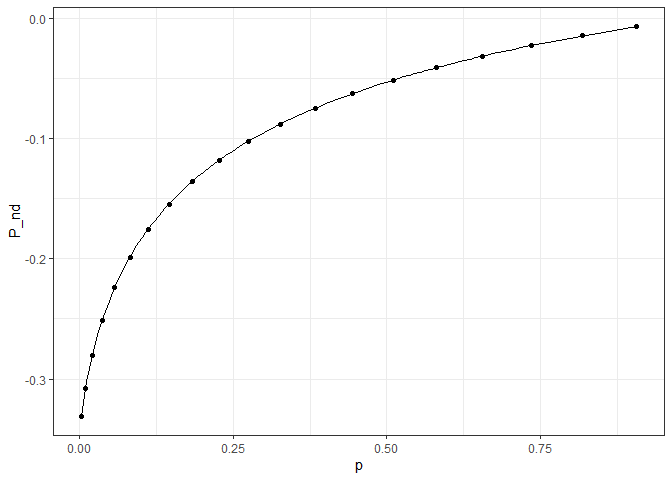

```r
# compute fixed points for each p
xi_random <- rnorm(1e4)   # random draw
df_Pnd <- tibble(p = ((1:20)/21)^2) %>%
  mutate(P_nd = map_dbl(.x = p, .f = compute_fixedpt_Gamma,
                        xi_random = xi_random,
                        sigma_x = sigma_x, alpha = alpha, beta = beta))
Pnd_splined <- splinefun(x = df_Pnd %>% pull(p),
                         y = df_Pnd %>% pull(P_nd))

# plot the estimate P_nd as a function of p
qplot(p, P_nd, data= df_Pnd) +
  stat_function(fun = Pnd_splined) +
  theme_bw()
```

```r
# Compute P_nd for each p
df <- df %>%
  mutate(P_nd = map_dbl(.x = p, .f = Pnd_splined))
```

- Now we can compute the utility of disclosure and thus the disclosure decision.

```r
df <- df %>%
  mutate(u = alpha * (x - P_nd) + beta + rnorm(N*Time)) %>%
  mutate(d = if_else(theta == 1 | u < 0, 0, 1))
df
```

```
## # A tibble: 30,000 x 9
##        i     t     p theta       e       x    P_nd      u     d
##    <int> <int> <dbl> <dbl>   <dbl>   <dbl>   <dbl>  <dbl> <dbl>
##  1     1     1 0.262     0  0.0376  0.0741 -0.106  -0.347     0
##  2     1     2 0.2       0  0.567   0.0683 -0.128   1.06      1
##  3     1     3 0.2       0  0.0583  0.0149 -0.128   1.64      1
##  4     1     4 0.2       0  0.856   0.192  -0.128   0.429     1
##  5     1     5 0.2       0  1.30    0.172  -0.128   1.42      1
##  6     1     6 0.2       0  0.523   0.156  -0.128   1.14      1
##  7     1     7 0.2       1 -1.22   NA      -0.128  NA         0
##  8     1     8 0.8       1  1.51   NA      -0.0163 NA         0
##  9     1     9 0.8       1 -0.600  NA      -0.0163 NA         0
## 10     1    10 0.8       0  0.138   0.0939 -0.0163 -0.459     0
## # ... with 29,990 more rows
```

- We delete the value of $x_t$ for non-disclosure firms.

```r
df <- df %>%
  mutate(x = if_else(d == 1, x, NA_real_))
df
```

```
## # A tibble: 30,000 x 9
##        i     t     p theta       e       x    P_nd      u     d
##    <int> <int> <dbl> <dbl>   <dbl>   <dbl>   <dbl>  <dbl> <dbl>
##  1     1     1 0.262     0  0.0376 NA      -0.106  -0.347     0
##  2     1     2 0.2       0  0.567   0.0683 -0.128   1.06      1
##  3     1     3 0.2       0  0.0583  0.0149 -0.128   1.64      1
##  4     1     4 0.2       0  0.856   0.192  -0.128   0.429     1
##  5     1     5 0.2       0  1.30    0.172  -0.128   1.42      1
##  6     1     6 0.2       0  0.523   0.156  -0.128   1.14      1
##  7     1     7 0.2       1 -1.22   NA      -0.128  NA         0
##  8     1     8 0.8       1  1.51   NA      -0.0163 NA         0
##  9     1     9 0.8       1 -0.600  NA      -0.0163 NA         0
## 10     1    10 0.8       0  0.138  NA      -0.0163 -0.459     0
## # ... with 29,990 more rows
```

- We look at the summary statistics and if that matches to Table II of the original paper.

```r
df %>%
  select(-i, -t) %>%
  psych::describe(skew = FALSE) %>%
  select(-vars)
```

```
##           n  mean   sd   min   max range   se
## p     30000  0.41 0.28  0.20  0.80  0.60 0.00
## theta 30000  0.38 0.49  0.00  1.00  1.00 0.00
## e     30000  0.00 0.74 -3.11  3.01  6.12 0.00
## x     14770  0.02 0.16 -0.59  0.61  1.21 0.00
## P_nd  30000 -0.09 0.05 -0.13 -0.02  0.11 0.00
## u     18455  0.90 1.09 -3.38  5.02  8.39 0.01
## d     30000  0.49 0.50  0.00  1.00  1.00 0.00
```

- Finally, we drop variables that are not observed.
  - In the next section, we check if the estimation procedure can recover the parameters.

```r
df_observed <- df %>%
  select(i, t, e, x, d)
df_observed
```

```
## # A tibble: 30,000 x 5
##        i     t       e       x     d
##    <int> <int>   <dbl>   <dbl> <dbl>
##  1     1     1  0.0376 NA          0
##  2     1     2  0.567   0.0683     1
##  3     1     3  0.0583  0.0149     1
##  4     1     4  0.856   0.192      1
##  5     1     5  1.30    0.172      1
##  6     1     6  0.523   0.156      1
##  7     1     7 -1.22   NA          0
##  8     1     8  1.51   NA          0
##  9     1     9 -0.600  NA          0
## 10     1    10  0.138  NA          0
## # ... with 29,990 more rows
```

```r
# save
save(df_observed, file = here::here("./middle/df_observed.RData"))
```

# Model Identification

```r
# parameters
alpha_vec <- c(0, 1, 5, 20)

# register cores
library(doParallel)
```

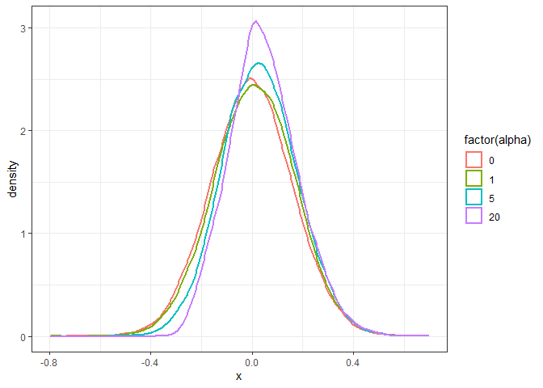

```r
cl <- parallel::makePSOCKcluster(4)
doParallel::registerDoParallel(cl)

xi_random <- rnorm(1e3)  # random draw

# simulate data for each alpha
obj = foreach (i = seq_along(alpha_vec),
               .packages = c('dplyr',
                             'purrr',
                             'tidyr',
                             'BertomeuMaMarinovic')) %dopar% {
                 simulate_model(
                   alpha_vec[i],
                   beta, sigma_x, sigma_e, p_11, p_01,
                   N = 5*1e3, Time = 20,
                   xi_random = xi_random
                 )
               }

# kill finished tasks
parallel::stopCluster(cl)

# combine data
temp <- list()
for(k in seq_along(alpha_vec)){
  temp[[k]] <- obj[[k]]$df %>%
    mutate(alpha = alpha_vec[k])
}
df_1 <- bind_rows(temp)

# plot
df_1 %>%
  filter(d == 1) %>%     # only disclosing sample
  select(x, alpha) %>%
  ggplot(aes(x, group = factor(alpha))) +
  geom_density(aes(colour = factor(alpha)),
                   size = 1,
                   alpha = .8) +
  theme_bw()
```

- Probability of disclosure for each $\beta$ and $\alpha$

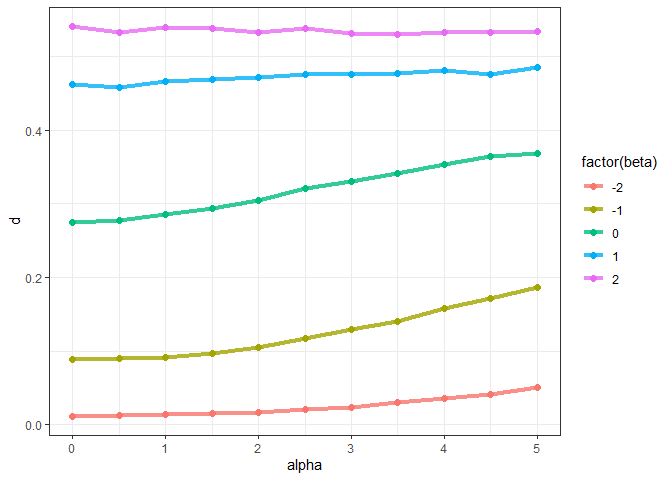

```r
# parameters
param_table <-
  expand_grid(alpha = seq(0, 5, .5),
              beta = -2:2) %>%
  as.matrix()

# register cores
cl <- parallel::makePSOCKcluster(8)
doParallel::registerDoParallel(cl)

# simulate data for each alpha
obj <-  foreach (i = 1:NROW(param_table),
               .packages = c('dplyr',
                             'purrr',
                             'tidyr',
                             'BertomeuMaMarinovic')) %dopar% {
                 BertomeuMaMarinovic::simulate_model(
                   param_table[i,1], param_table[i,2],
                   sigma_x, sigma_e, p_11, p_01,
                   N = 5*1e3, Time = 20,
                   xi_random = xi_random
                 )
               }

# kill finished tasks
parallel::stopCluster(cl)

# combine data
temp <- list()
for(k in 1:NROW(param_table)){
  temp[[k]] <- obj[[k]]$df %>%
    mutate(alpha = param_table[k,1],
           beta = param_table[k,2])
}
df_2 <- bind_rows(temp)

df_2 %>%
  group_by(alpha, beta) %>%
  summarise(d = mean(d),
            .groups = "drop") %>%
  ggplot(aes(x = alpha, y = d, group = factor(beta))) +
  geom_point(aes(colour = factor(beta)),
                   size = 2) +
  geom_line(aes(colour = factor(beta)),
            size = 1.5,
            alpha = .8) +
  theme_bw()
```

- Nondisclosure price at $p=0.25$ and average disclosure price $\mathbb{E}[x_t \mid d_t = 1]$

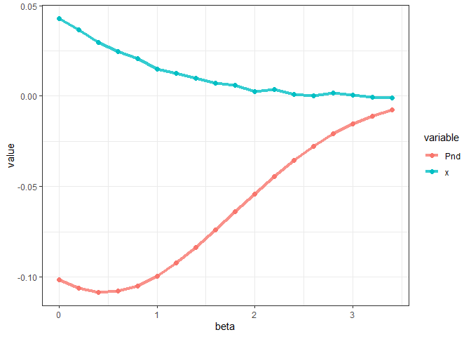

```r
# parameters
beta_vec <- seq(0, 3.5, .2)

# register cores
library(doParallel)
cl <- parallel::makePSOCKcluster(4)
doParallel::registerDoParallel(cl)

xi_random <- rnorm(1e3)  # random draw

# simulate data for each alpha
obj <- foreach (i = seq_along(beta_vec),
               .packages = c('dplyr',
                             'purrr',
                             'tidyr',
                             'BertomeuMaMarinovic')) %dopar% {
                 simulate_model(
                   alpha, beta_vec[i],
                   sigma_x, sigma_e, p_11, p_01,
                   N = 5 * 1e3, Time = 20,
                   xi_random = xi_random
                 )
               }

# kill finished tasks
parallel::stopCluster(cl)

# combine data
temp <- list()
for(k in seq_along(beta_vec)){
  temp[[k]] <- obj[[k]]$df %>%
    mutate(beta = beta_vec[k]) %>%
    mutate(Pnd = obj[[k]]$Pnd(0.25))
}
df_3 <- bind_rows(temp)
rm(obj)

# plot
df_3 %>%
  group_by(beta) %>%
  summarize(Pnd = mean(Pnd),
            x = mean(x, na.rm = TRUE),
            .groups = "drop") %>%
  pivot_longer(-beta, names_to = "variable") %>%
  ggplot(aes(beta, value)) +
  geom_point(aes(colour = variable), size = 2) +
  geom_line(aes(colour = variable), size = 1.5, alpha = .8) +
  theme_bw()
```

- The “disclosure premium” for each $\beta$.

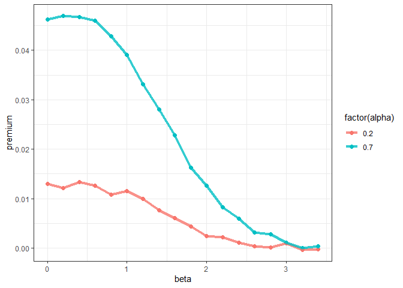

```r
# parameters
param_table <-
  expand_grid(alpha = c(0.2, 0.7),
              beta = seq(0, 3.5, 0.2)) %>%
  as.matrix()

# register cores
cl <- parallel::makePSOCKcluster(8)
doParallel::registerDoParallel(cl)

# simulate data for each alpha
obj <-  foreach (i = 1:NROW(param_table),
               .packages = c('dplyr',
                             'purrr',
                             'tidyr',
                             'BertomeuMaMarinovic')) %dopar% {
                 BertomeuMaMarinovic::simulate_model(
                   param_table[i,1], param_table[i,2],
                   sigma_x, sigma_e, p_11, p_01,
                   N = 1e4, Time = 20,
                   xi_random = xi_random
                 )
               }

# kill finished tasks
parallel::stopCluster(cl)

# combine data
temp <- list()
for(k in 1:NROW(param_table)){
  temp[[k]] <- obj[[k]]$df %>%
    mutate(alpha = param_table[k,1],
           beta = param_table[k,2]) %>%
    mutate(Pnd = obj[[k]]$Pnd(0.25))
}
df_4 <- bind_rows(temp)

df_4 %>%
  group_by(alpha, beta) %>%
  summarise(x = mean(x, na.rm = TRUE),
            Pnd = mean(Pnd),
            .groups = "drop") %>%
  mutate(premium = x - Pnd) %>%
  ggplot(aes(beta, premium)) +
  geom_point(aes(colour = factor(alpha)),
                   size = 2) +
  geom_line(aes(colour = factor(alpha)), size = 1.5,
            alpha = 0.8) +
  theme_bw()
```

# Estimation

- Using the simulated observed data, `df_observed`, we estimate the parameters.
- Several details that are not (probably) not mentioned in the article.
  - Estimation of $\Phi(k_0)$ and $\Phi(k_1)$.
    - I guess they used MLE, but how did they decide the initial value of $p_t$?
  - The computation of $L_t^0$.
    - Computing $v_t$ involves numerical integration. How did they do that?
- In this note, the estimation is conducted by the following steps:
1. Estimate $\sigma_e$ from the observed earnings.
2. Estimate the rest of the parameters using MLE.
   - For each set of parameters, we compute $P^{nd}$ and then compute the likelihood function.
   - The initial value of $p_t$ is drawn from the beta distribution.
- `compute_likelihood` computes the likelihood.
  - To compute likelihood for a set of parameters, it takes about 10 seconds.

```r
# data
load(here::here("./middle/df_observed.RData"))
param <- c(alpha = 2.54, beta = .67, sigma_x = .32, p_11 = .8, p_01 = .2)

# random draw (should be outside of parameter iteration)
sigma_e_hat <- sd(df_observed %>% pull(e))
x_random <- rnorm(1e3,
                  mean = sigma_x^2/sigma_e_hat^2,
                  sd = sqrt(sigma_x^2 * (1 - sigma_x^2/sigma_e_hat^2)))
xi_random <- rnorm(1e3)

compute_likelihood(param, df_observed, xi_random, x_random)
```

```
## [1] 5724.495
```

- Optimization

```r
# # make cluster
# library(parallel)
# cl <- makeCluster(4)
# setDefaultCluster(cl = cl)
# clusterExport(cl, "df_observed")
# clusterEvalQ(cl, {library(dplyr); library(magrittr); library(purrr);
#                   library(tidyr); library(BertomeuMaMarinovic)})
#
# # optimization
# res <- optimParallel::optimParallel(
#   param, compute_likelihood, df = df_observed,
#   method = "L-BFGS-B",
#   lower = c(-10, -10, 0.001, 0.001, 0.001),  # param = (alpha, beta, sigma_x, p_11, p_01)
#   upper = c(10, 10, 5, sigma_e_hat, 0.999),  # sigma_e < sigma_x by construction
#   control = list(fnscale = -1,
#                  trace = 6,
#                  REPORT = 1),
#   parallel = list(loginfo = TRUE, forward = FALSE))
#
# # stop cluster
# setDefaultCluster(cl=NULL); stopCluster(cl)
#
# res
```

- Finally, we check the identification by plotting the likelihood around the true values.

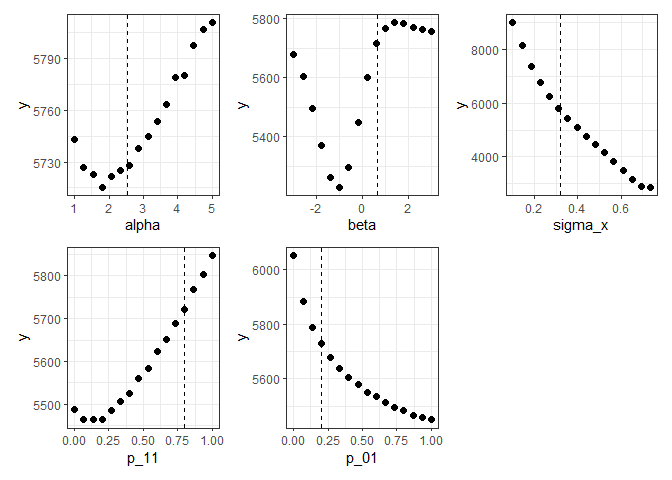

```r
plot_list <- list()
for(i in 1:5){
  plot_list[[i]] <- plot_ll(param, df_observed, i,
                            xi_random, x_random)
}

wrap_plots(plot_list)
```